# Portfolio

# Identification of Causes by Patient Factor Regarding TP53 Mutations in Lung Cancer

Migyeong Moon, 2020140439, Food Bioscience and Technology, Korea University

## 1. Introduction

One of the most common mutations in human cancer is somatic mutations in the TP53 gene (Olivier et al., 2010). TP53 mutation negatively correlated with MAPK pathways deeply involved in cancer. It is also associated with DNA replication, DNA topology regulation, and DNA damage response (Chen et al., 2020). These positive correlations of TP53 mutations correspond with known synthetic interactions (Yeo et al., 2016), which provides information on the regulations of critical pathways in lung cancer by TP53. Therefore, this report focuses on the distribution of genetic alterations associated with the TP53 mutation. Genes positively related to TP53 mutation are shown in the following figure (Chen et al., 2020).

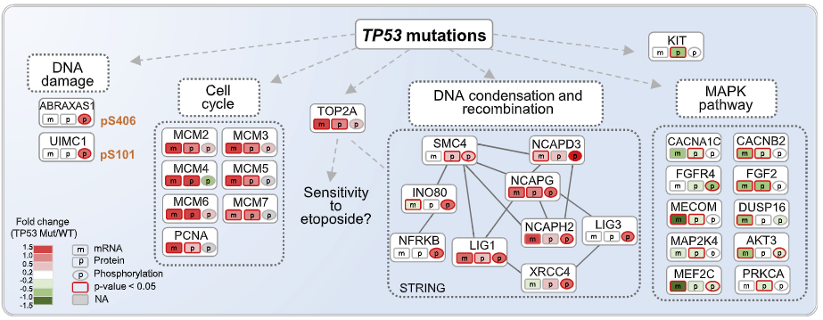

This report aims to identify patient factors associated with the TP53 mutation in a cohort of Taiwan. Among the genes related to TP53, we will investigate the Cell cycle genes, which appears to be closely associated with the TP53 mutations in the figure above. We will plot the relationship between the genomic alterations positively correlated with TP53 mutation and the patient factor using the dataset. After the figures explain the correlation, the distinct characteristics of patients with genetic mutations associated with TP53 will be discussed.

## 2. Setting Data Frame

```r
# read data
library(tidyverse)
library(dplyr)
library(readxl)
read_excel("1-s2.0-S0092867420307431-mmc1.xlsx", sheet=2) -> dat1
read_excel("1-s2.0-S0092867420307431-mmc1.xlsx", sheet=4) -> dat2
```

```
* `` -> ...1
* `` -> ...2
* ...
```

```r
read_excel("1-s2.0-S0092867420307431-mmc1.xlsx", sheet=5) -> dat3
```

In the dataset, females, and non-smokers account for most of the samples. Therefore, this report will analyze data by limiting them to females and non-smokers to minimize the impact of factors other than the specific patient factors.

The information to be used in the three data frames is as follows.

In dat1, patient ID, gender, age, smoking status, Primary Tumor Location.

In dat2, the presence of TP53 mutations.

In dat3, mRNA expression data of genes positively correlated with TP53 mutations.

### A. Manipulating dat1

First, the columns of dat1 are as follows. dat1 is a dataframe about the patient’s basic information.

```r
colnames(dat1)
```

```
[1] "ID"                     "Proteome_Batch"
[3] "Gender"                 "Age"
[5] "Smoking Status"         "Histology Type"
[7] "Stage"                  "EGFR_Status"
[9] "Primary Tumor Location"
```

To extract only the information mentioned earlier, we create a new data frame called dat4 using columns 1, 3, 4, 5, and 9 of dat1.

```r
dat4 <- dat1[c(1,3,4,5,9)]
```

### B. Manipulating dat2

dat2 is a data frame about gene mutation information. Unlike dat1, dat2 has a patient ID in the row, so it must be modified to appear as a column. First, in dat2, the existing column name does not match the content, so column 1 is designated as the column name instead. Next, TP53 is extracted from genes using filter function because only mutations in the TP53 gene, not other genes, will be used in the data frame. Finally, the patient ID is displayed in columns using the pivot_longer function.

```r
names(dat2) <- dat2[1,]
dat2 <- dat2[-1, -c(2, 3)] %>% # first step
  filter(Gene=="TP53") %>% # second step
  pivot_longer(cols=-Gene, names_to="ID", values_to="TP53_mut") # final step
```

### C. Manipulating dat3

dat3 is a data frame containing mRNA expression information of genes. Like dat2, the patient ID is displayed in a row in dat3. Therefore, it is expressed as a column using the pivot_longer function. In addition, the information to be used is the cell cycle genes positively associated with the TP53 mutations, so only information about those genes is extracted using the filter function.

The genes to be found in dat3 are as follows. MCM2, MCM3, MCM4, MCM5, MCM6, MCM7, PCNA.

```r
colnames(dat3)
```

```
 [1] "gene"            "ensembl_gene_id" "Median"
 [4] "P002"            "P006"            "P007"
 [7] "P009"            "P010"            "P011"
[10] "P012"            "P013"            "P015"
[13] "P016"            "P017"            "P018"
[16] "P019"            "P020"            "P021"
[19] "P022"            "P023"            "P024"
[22] "P025"            "P026"            "P027"
[25] "P028"            "P029"            "P030"
[28] "P031"            "P032"            "P033"
[31] "P034"            "P036"            "P037"
[34] "P038"            "P039"            "P040"
[37] "P042"            "P043"            "P044"
[40] "P045"            "P048"            "P049"
[43] "P050"            "P051"            "P052"
```

[output cut: 16 more lines]

```r
dat3 <- dat3[,-c(2, 3)] %>% # Columns 2 and 3 are not required.
  filter(gene %in% c("MCM2", "MCM3", "MCM4", "MCM5", "MCM6", "MCM7", "PCNA")) %>%
  pivot_longer(cols=-gene, names_to="ID", values_to="mRNA_exp")
```

### D. Merging the dataframes

The data frames previously manipulated are integrated into one data frame called dat5. In this process, information is combined based on the patient ID. In dat2, column1 is the same information as TP53, so it is removed.

```r
dat5<- merge(dat4,dat2[,-1], by="ID") %>%
  merge(dat3, by="ID")
```

Also since we will only use data from females, non-smokers, we modify the data using filter function.

```r
dat5 <- dat5 %>% filter(Gender=="Female", `Smoking Status`=="Nonsmoke")
```

To distinguish between people who have TP53 mutations and those who do not, let’s create a new data frame called dat6, and dat7

```r
dat6<- dat5 %>% filter(!is.na(TP53_mut))
dat7<- dat5 %>% filter(is.na(TP53_mut))
```

## 3. Visualization

```r
library(ggplot2)
```

### A. Figure 1.

Figure 1 shows the expression of the cell cycle genes associated with the TP53 mutations according to age. First, samples of patients with TP53 mutation and those who do not in females and non-smokers are shown separately. Also, since this report aims to investigate the causes of lung cancer regarding TP53 mutations, I try to examine the correlation between cell cycle gene expression and patient factors using regression model lines. However, the figure do not show TP53 mutant patients aged 65 or older because of a lack of data.

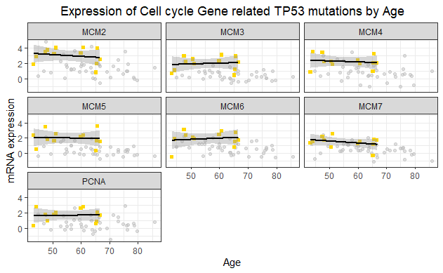

```r
Figure1 <- dat7 %>% group_by(gene) %>%
  ggplot(aes(x=Age, y=mRNA_exp)) +
  geom_point(alpha=0.5, color="grey") +
  geom_point(data=dat6, shape=15, color="gold") +
  geom_smooth(data=dat6, method="lm", color="black") +
  theme_bw()+
  facet_wrap(~ gene) +
  labs(x = "Age",
       y = "mRNA expression",
       title = "Expression of Cell cycle Gene related TP53 mutations by Age")+
  theme(plot.title = element_text(hjust = 0.5))
Figure1
```

### B. Figure 2.

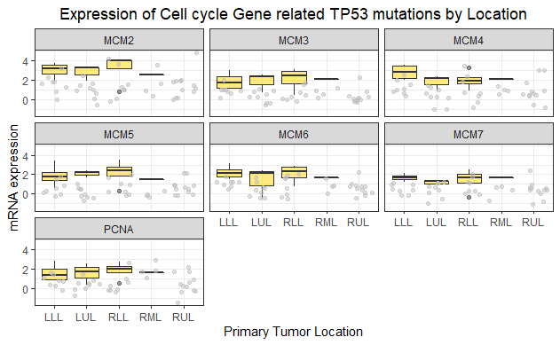

```r
Figure2 <- dat7 %>% group_by(gene) %>%
  ggplot(aes(x=`Primary Tumor Location`, y=mRNA_exp)) +
  geom_boxplot(data=dat6,alpha=0.5, shape=15, fill="gold") +
  geom_jitter(alpha=0.5, color="grey") +
  theme_bw()+
  facet_wrap(~ gene) +
  labs(x = "Primary Tumor Location",
       y = "mRNA expression",
       title = "Expression of Cell cycle Gene related TP53 mutations by Location") +
  theme(plot.title = element_text(hjust = 0.5))
Figure2
```

## 4. Discussion

First, the relationship between the cell cycle genes and age shown in Figure 1 showed similar expression tendencies for the 40s- 60s patients. In the case of MCM2 and MCM7 genes, patients with TP53 mutations tended to decrease with age. However, MCM2 and MCM7 genes were not related to TP53 mutation because TP53 mutant-free patients also tended to fall. Therefore, the age-dependent effect was considered insignificant in the case of the cell cycle gene associated with the TP53 mutation.

## References

Chen, Y., Roumeliotis, T., Chang, Y., Chen, C., Han, C., Lin, M., …, Wu, P. (2020). Proteogenomics of Non-smoking Lung Cancer in East Asia Delineates Molecular Signatures of Pathogenesis and Progression. Cell. 182(1). 226-244.

Olivier, M., Hollstein, M., & Hainaut, P. (2010). TP53 Mutations in Human Cancers: Origins, Consequences, and Clinical Use. Cold Spring Harb Perspect Biol. 2(1). a001008.

Yeo, C.Q.X, Alexander, I., Lin, Z., Lim, S., Aning, O.A., Kumar, R., …, Cheok, C.F. (2016). p53 Maintains Genomic Stability by Preventing Interference between Transcription and Replication. Cell Rep. 15, 132-146.